# L10-Build Map With Layers

## Overlay Route

```
Scale on map varies by more than 10%, scale bar may be inaccurate
```

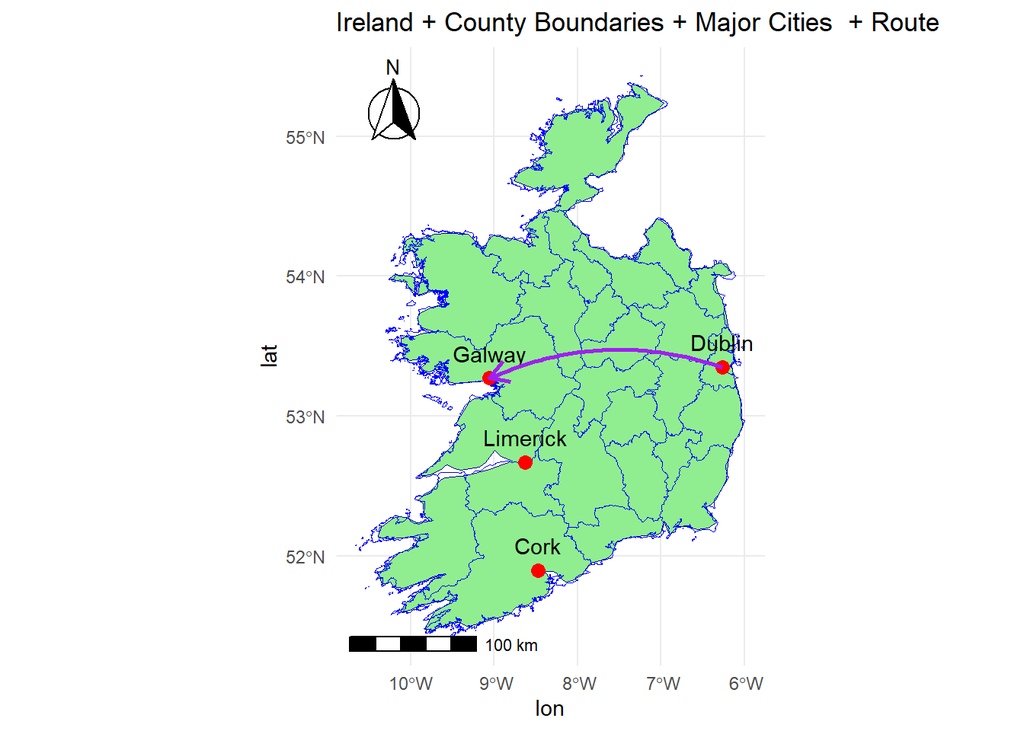

```r
# Ireland base map
ggplot2::ggplot() +
  geom_sf(data = ireland, fill = "lightgreen", color = "darkblue") +
  geom_sf(data = countyshapes, fill = NA, color = "blue", size = 0.5) +

  # Cities Data
  geom_point(data = cities, aes(x = lon, y = lat), color = "red", size = 3) +
  geom_text_repel(data = cities, aes(x = lon, y = lat, label = name), vjust = -1) +

  # Add a curved line from Dublin to Galway
  geom_curve(aes(x = -6.2603, y = 53.3498, xend = -9.0568, yend = 53.2707),
             curvature = 0.2, color = "purple", linewidth = 1,
             arrow = arrow(length = unit(0.15, "inches"))) +

  # Scale bar and north arrow
  annotation_scale(location = "bl", width_hint = 0.5) +
  annotation_north_arrow(location = "tl", which_north = "true", style = north_arrow_fancy_orienteering) +

  # Theme and title
  theme_minimal() +
  ggtitle("Ireland + County Boundaries + Major Cities  + Route")
```

## Overlay with Income Data for each County

Using data from the CSO which gives median income per electoral district, summarise to get the median income per county and then overlay on the map.

```
Scale on map varies by more than 10%, scale bar may be inaccurate
```

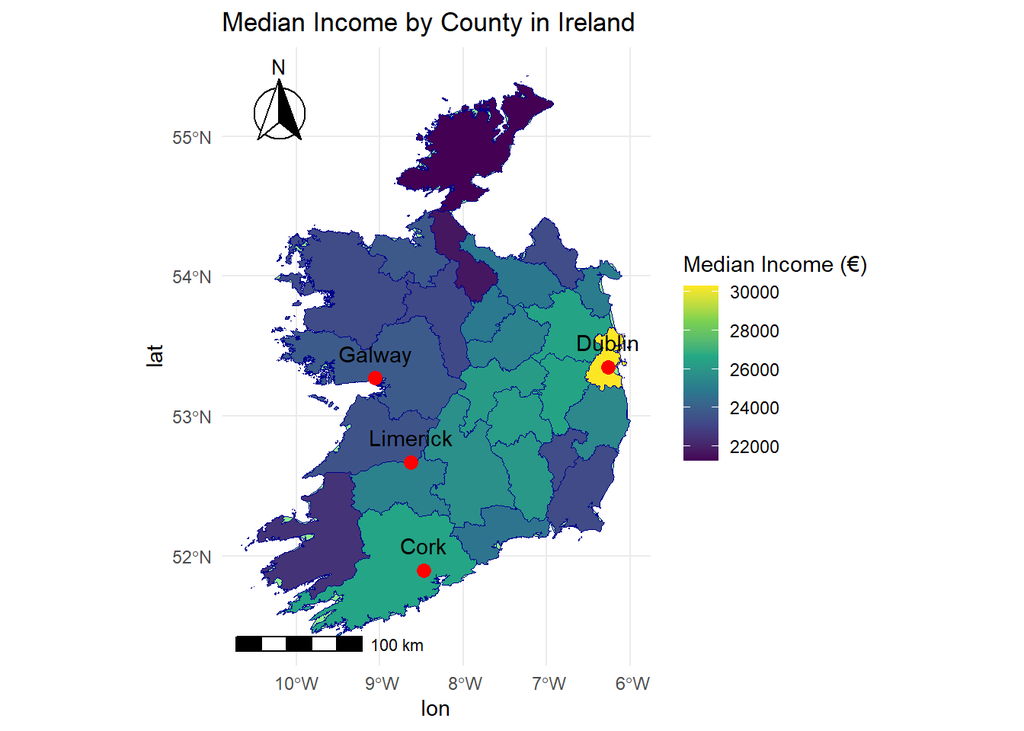

```r
# Read in a file from CSO data of median income per electoral region
incomeloc <-file.path(mydata,"MedianIncomeIreland.csv" )
countyincome <-read.csv(incomeloc)

# Using a regular expression, extract county name after "Co." or Ending with Dublin, Cork City or Tipperary and add to the same dataset as column county
countyincome$county <- str_extract(countyincome$Electoral.Division,
                                      "(?<=Co\\. )\\w+|Dublin$|Cork City$|Tipperary$")

# Regular Expression explanation:
# (?<=Co\. )\w+ - This is a lookbehind (?<=...), which ensures that the match only occurs if it is preceded by "Co. " (e.g., "Co. Mayo").
# \w+ matches one or more word characters (letters, numbers, or underscores), so it captures county names like "Mayo", "Galway", etc., after "Co. ".
# The | means OR.
# Dublin$ matches "Dublin" only if it appears at the end of the string ($ means end of the string).
# Cork City$ Matches "Cork City" only if it appears at the end of the string.
#  Tipperary$ Matches "Tipperary" only if it appears at the end of the string.

# Replace Cork City by Cork
countyincome <- countyincome %>%
  mutate(county = case_when(
    county == "Cork City" ~ "Cork",
    TRUE ~ county
  ))
# Rename column "VALUE" to "avg_income"
countyincome <- countyincome %>%
  rename(mdn_income = VALUE)
countyincome <- na.omit(countyincome)

# Summarize avg_income by county_name, omitting nas
summary_df <- na.omit(countyincome) %>%
  group_by(county) %>%
  summarize(mdn_income = median(mdn_income, na.rm = TRUE))


# Merge income data with spatial county boundaries
counties_income <- countyshapes %>%
  inner_join(summary_df, by = c("NAME_1" = "county")) %>% # Ensure column names match
  st_as_sf()  # Ensure it remains a spatial object with geometry

# Plot Map with Income Data, Boundaries, and Cities
ggplot2::ggplot() +
  # Base Ireland map
  geom_sf(data = ireland, fill = "lightgreen", color = "darkblue") +

  # County boundaries
  geom_sf(data = countyshapes, fill = NA, color = "blue", size = 0.5) +

  # Income overlay
  geom_sf(data = counties_income, aes(fill = mdn_income), color = "darkblue") +
  scale_fill_viridis_c(name = "Median Income (€)", na.value = "grey50") +

  # Cities layer
  geom_point(data = cities, aes(x = lon, y = lat), color = "red", size = 3) +
  geom_text_repel(data = cities, aes(x = lon, y = lat, label = name), vjust = -1) +

  # Scale bar and compass
  annotation_scale(location = "bl", width_hint = 0.5) +
  annotation_north_arrow(location = "tl", which_north = "true", style = north_arrow_fancy_orienteering) +

  # Theme and title
  theme_minimal() +
  ggtitle("Median Income by County in Ireland")
```

Note: The scale issue arises because Ireland’s shape is not perfectly uniform in a simple projected coordinate system, which can distort the accuracy of the scale bar. This is a projection distortion. You need to choose an appropriate co-ordinate system. The Irish Transverse Mercator (EPSG:2157) is the best choice for Ireland.

## Irish Traverse Mercator Projection

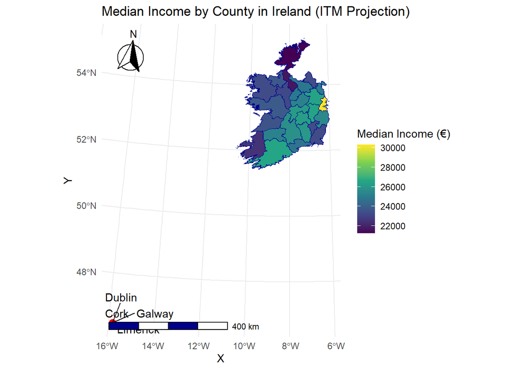

```r
# Define a new projection (Irish Traverse Mercator)
crs_itransm <- 2157

# Reproject all spatial data
ireland_proj <- sf::st_transform(ireland, crs_itransm)
counties_proj <- sf::st_transform(countyshapes, crs_itransm)
counties_income_proj <- sf::st_transform(counties_income, crs_itransm)

# Convert city coordinates to projected CRS
cities_proj <- cities %>%
  sf::st_as_sf(coords = c("lon", "lat"), crs = 2157) %>%
  sf::st_transform(crs_itransm) %>%
  sf::st_coordinates() %>%
  as.data.frame() %>%
  mutate(name = cities$name)

# Plot using the new projection
ggplot2::ggplot() +
  geom_sf(data = ireland_proj, fill = "lightgreen", color = "darkblue") +
  geom_sf(data = counties_proj, fill = NA, color = "blue", size = 0.5) +
  geom_sf(data = counties_income_proj, aes(fill = mdn_income), color = "darkblue") +
  scale_fill_viridis_c(name = "Median Income (€)", na.value = "grey50") +
  geom_point(data = cities_proj, aes(x = X, y = Y), color = "red", size = 3) +
  geom_text_repel(data = cities_proj, aes(x = X, y = Y, label = name), vjust = -1) +
  annotation_scale(location = "bl", width_hint = 0.5, unit_category = "metric",
                   bar_cols = c("darkblue", "white")) +
  annotation_north_arrow(location = "tl", which_north = "true",
                         style = north_arrow_fancy_orienteering) +
  theme_minimal() +
  ggtitle("Median Income by County in Ireland (ITM Projection)")
```

# Alternate Map Projections

## Lambert Projection

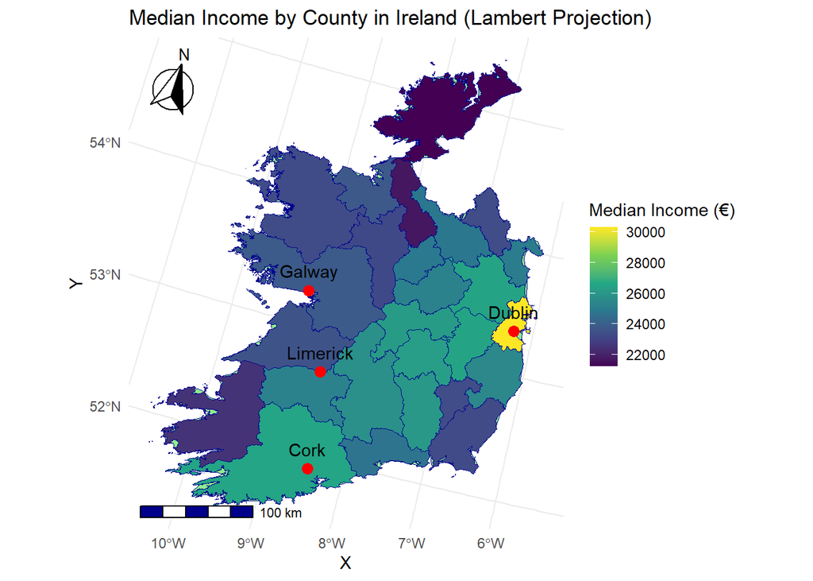

```r
# Define a new projection (Lambert Conformal Conic)
crs_lambert <- 3035

# Reproject all spatial data
ireland_proj <- sf::st_transform(ireland, crs_lambert)
counties_proj <- sf::st_transform(countyshapes, crs_lambert)
counties_income_proj <- sf::st_transform(counties_income, crs_lambert)

# Convert city coordinates to projected CRS
cities_proj <- cities %>%
  sf::st_as_sf(coords = c("lon", "lat"), crs = 4326) %>%    # Start with WGS84
  sf::st_transform(crs = crs_lambert) %>%                   # Project to Lambert
  sf::st_coordinates() %>%                                  # Extract coordinates
  as.data.frame() %>%
  mutate(name = cities$name)                            # Reattach city names


# Plot using the new projection
ggplot2::ggplot() +
  geom_sf(data = ireland_proj, fill = "lightgreen", color = "darkblue") +
  geom_sf(data = counties_proj, fill = NA, color = "blue", size = 0.5) +
  geom_sf(data = counties_income_proj, aes(fill = mdn_income), color = "darkblue") +
  scale_fill_viridis_c(name = "Median Income (€)", na.value = "grey50") +
  geom_point(data = cities_proj, aes(x = X, y = Y), color = "red", size = 3) +
  geom_text_repel(data = cities_proj, aes(x = X, y = Y, label = name), vjust = -1) +
  annotation_scale(location = "bl", width_hint = 0.5, unit_category = "metric",
                   bar_cols = c("darkblue", "white")) +
  annotation_north_arrow(location = "tl", which_north = "true",
                         style = north_arrow_fancy_orienteering) +
  theme_minimal() +
  ggtitle("Median Income by County in Ireland (Lambert Projection)")
```

## Azimuthal Projection

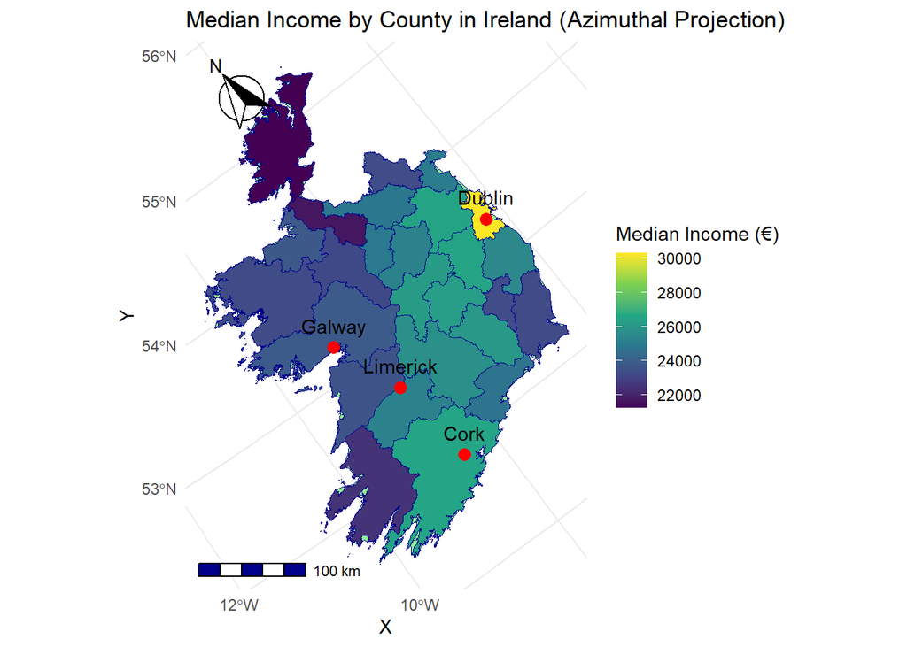

```r
# Define Azimuthal Equidistant projection
crs_azimuthal <- 3413  # North Pole-centered

# Reproject spatial data
ireland_proj <- sf::st_transform(ireland, crs_azimuthal)
counties_proj <- sf::st_transform(countyshapes, crs_azimuthal)
counties_income_proj <- sf::st_transform(counties_income, crs_azimuthal)

# Convert city coordinates to projected CRS
cities_proj <- cities %>%
  sf::st_as_sf(coords = c("lon", "lat"), crs = 4326) %>%
  sf::st_transform(crs_azimuthal) %>%
  sf::st_coordinates() %>%
  as.data.frame() %>%
  mutate(name = cities$name)

# Plot the map using Azimuthal Equidistant projection
ggplot2::ggplot() +
  geom_sf(data = ireland_proj, fill = "lightgreen", color = "darkblue") +
  geom_sf(data = counties_proj, fill = NA, color = "blue", size = 0.5) +
  geom_sf(data = counties_income_proj, aes(fill = mdn_income), color = "darkblue") +
  scale_fill_viridis_c(name = "Median Income (€)", na.value = "grey50") +
  geom_point(data = cities_proj, aes(x = X, y = Y), color = "red", size = 3) +
  geom_text_repel(data = cities_proj, aes(x = X, y = Y, label = name), vjust = -1) +
  annotation_scale(location = "bl", width_hint = 0.5, unit_category = "metric",
                   bar_cols = c("darkblue", "white")) +
  annotation_north_arrow(location = "tl", which_north = "true",
                         style = north_arrow_fancy_orienteering) +
  theme_minimal() +
  ggtitle("Median Income by County in Ireland (Azimuthal Projection)")
```